# Excercise - Lecture 1

Giuseppe Ragusa

12 September, 2016

## General Information

**Giuseppe Ragusa**:

- gragusa@luiss.it
- www.gragusa.org
- Professor at Luiss Business School and Economics and Finance Department
- Research in econometric methods, labour economics, macro models and computational methods

**Teaching method:**

- Traditional lecture 40%
- Individual exercises 10%
- Cases studies 35%
- Presentations and assignments 15%

**Assessment method:**

- Written test 50%
- Individual work executed during the course (e.g. assignments, paper writing, etc) 10%
- Team work executed during the course 40%

**Intended Learning Outcomes:**

1. Develop an appreciation for what is involved in learning from data.
2. Understand a wide variety of learning algorithms.
3. Understand how to apply a variety of learning algorithms to data .
4. Understand how to perform evaluation of learning algorithms and model selection.
5. Improve computer programming skills.

**Material:**

- Slides (PDF)
- Code (language: R)

**Reference**:

The elements of statistical learning, Friedman, Jerome, Trevor Hastie, and Robert Tibshirani. Springer, Berlin: Springer series in statistics, 2001. (Available free PDF on-line)

# But you will need Data…

[figure not shown]

# …And a powerful program

[figure not shown]

**About R**

Pros:

- Open Source
- Object oriented language
- Widely used by statistical communities
- Flexible, rich of packages and built-in functions

Cons: Lower efficiency then other languages (ex: C, Julia).

For installation, packages and other issues, see the appendix slides.

# Learning Curve

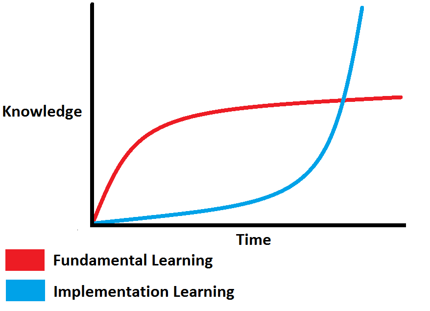

# Discussion: Prediction VS Modelling?

**Purpose of modelling?**

- Investigate causal relationships among variables
- Assess causal relationship among variables under certain assumptions
- Estimate the true relationship between variables
- No purpose: pure masochism

**Purpose of predicting?**

- Same of modelling
- Investigate causal relationship among variables and predict future variables
- Make accurate predictions with small errors on new observations
- Create a black box function and make predictions with no error

# Supervised Learning

“Supervised learning is the machine learning task of inferring a function from labeled training data”.

**Two cases:**

- Regression problem: continous output variable (e.g. inflation)
- Classification problem: discrete output variable (e.g. whether a patient has a disease)

**Examples:**

Regression:  
given data about the size of houses on the real estate market, try to predict their price. Price as a function of size is a continuous output.

Classification:  
try to predict whether houses sell at more then 500 000 euro, between 250 000 and 500 000 euro or they cost less then 250 000 according to their size.

# Unsupervised Learning

Unsupervised learning is the machine learning task of inferring a function to describe hidden structure from unlabeled data.

The main difference between supervised and unsupervised learning is that there is no output variable in the data and it must estimated using alternative techniques (GMM, NN, etc.).

The first part of the course will be about supervised learning algorithms.

## Linear model: review

Y is a vector of response variables: $\rightarrow Y = (y_1, y_2, ... , y_n)$

**X** is a vector of explanatory variables. $\rightarrow$ Data: $(y_1, x_1), (y_2, x_2), ... , (y_n, x_n)$

$$y_i = f(x_i) + \epsilon_i$$

for some unknown function $f$.

First approach to approximate $f$ with $\hat{f}$:

$$\underset{\hat{f}}{argmin}{E[(Y - f(\textbf{X}))^2]} = E[Y|\textbf{X}]$$

In a linear model with a single variable:

$$y_i = \beta_0 + \beta_1 x_i + \epsilon_i$$

if $E[\epsilon_i | x_i ] = 0$ then:

$$E[y_i | x_i] = \beta_0 + \beta_1 x_i$$

**Estimation of the coefficients**

Objective function:

$$\underset{\beta_0, \beta_1}{argmin}{\sum_{i=1}^n(y_i - \beta_0 - \beta_1x_i)^2}$$

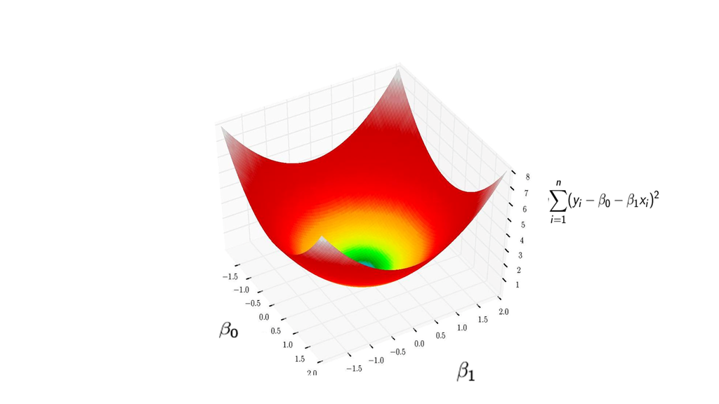

# Matrix Notation

Y is a vector of response variables: $\rightarrow Y = (y_1, y_2, ... , y_n)$

X is a N x K matrix of explanatory variables:

$$X=
\begin{bmatrix}
1 & ... & \textbf{X}_1 & ... \\
1 & ... & \textbf{X}_2 & ... \\
: & ... & \textbf{X}_3 & ... \\
1 & ... & \textbf{X}_n & ... \\
\end{bmatrix}$$

$\hat{f}(X): \mathbb{R}^k \rightarrow \mathbb{R}$

Linear model: $E[Y|X] = \beta_0 + \beta_1 x_{1,i} + ... + \beta_k x_{k,i} = X\beta$

Objective function:

$$RSS(\beta) = {(Y - X \beta)'(Y-X\beta)}$$

To find the minimum of the objective function:

$$\frac{dRSS(\beta)}{\beta} = 0$$

**Linear Projection**

$$\frac{dRSS(\beta)}{\beta} = 0$$

$\hat{\beta} = (\beta_0, \beta_1, ... , \beta_k)$

$$\hat{\beta}^{OLS} = (X^TX)^{-1}(X^TY)$$

The general definition of the error:

$$SE(\hat{\beta}) = (X^TX)^{-1} (\sum_{i=1}^n \epsilon_i^2 x_i^Tx_i) (X^TX)^{-1}$$

**Underlying assumptions**

- $E[\epsilon_i | x_i] = 0$
- $E|X^2| < \infty$
- $X'X$ is invertible

## Example: Predict Forest Fires

517 observations  
12 explanatory variable: humidity, day of the week, month, temperature, rain , wind, lat, long and other climate indicators 1 continuous dependent variable: area burned

Objective: predict forest fires

```r
forest.fires <- read.csv("./data/forestfires.csv")

dim(forest.fires)
```

```
## [1] 517  13
```

```r
names(forest.fires)
```

```
##  [1] "X"     "Y"     "month" "day"   "FFMC"  "DMC"   "DC"    "ISI"
##  [9] "temp"  "RH"    "wind"  "rain"  "area"
```

Explore the data

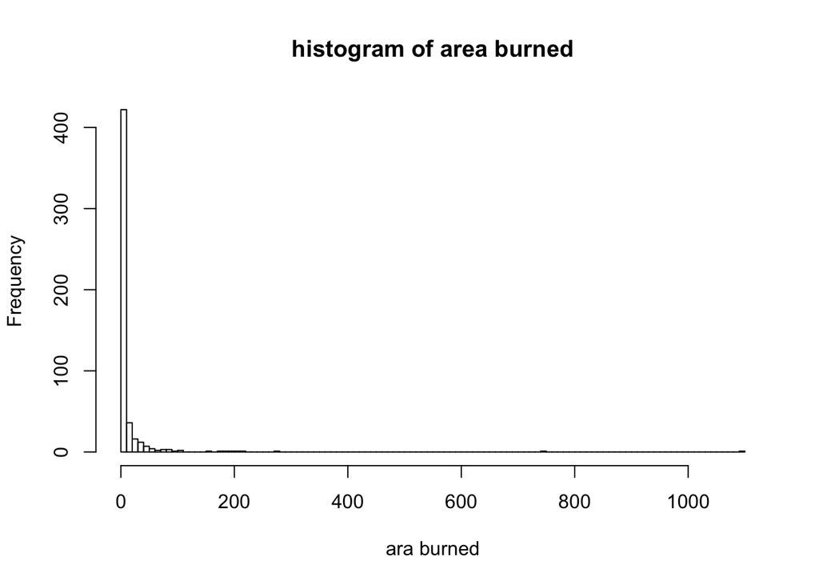

```r
## Explore the dependent variable

y <- forest.fires$area

hist(y, breaks=100, main="histogram of area burned", xlab="ara burned")
```

```r
length(y[forest.fires$area < 40])
```

```
## [1] 486
```

```r
length(y[forest.fires$area < 150])
```

```
## [1] 508
```

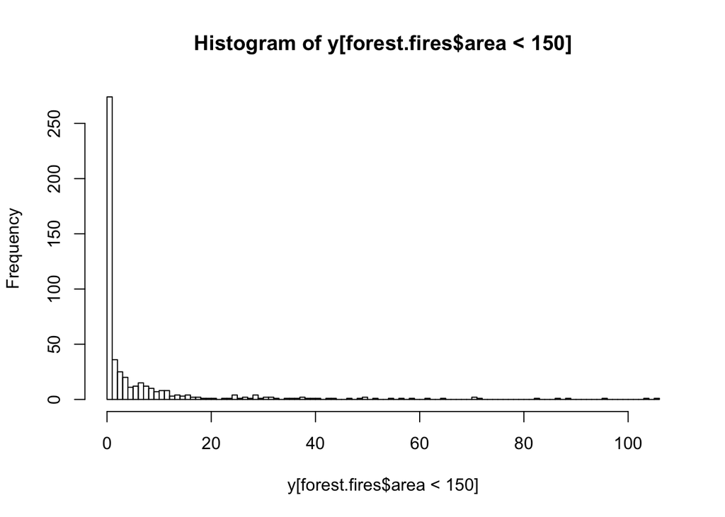

```r
hist(y[forest.fires$area < 150], breaks=100)
```

# Linear Regression

```r
reg1 <- lm(area ~ temp, data=forest.fires)

summary(reg1)
```

```
##
## Call:
## lm(formula = area ~ temp, data = forest.fires)
##
## Residuals:
##     Min      1Q  Median      3Q     Max
##  -27.34  -14.68  -10.39   -3.42 1071.33
##
## Coefficients:
##             Estimate Std. Error t value Pr(>|t|)
## (Intercept)  -7.4138     9.4996  -0.780   0.4355
## temp          1.0726     0.4808   2.231   0.0261 *
## ---
## Signif. codes:  0 '***' 0.001 '**' 0.01 '*' 0.05 '.' 0.1 ' ' 1
##
## Residual standard error: 63.41 on 515 degrees of freedom
## Multiple R-squared:  0.009573,   Adjusted R-squared:  0.00765
## F-statistic: 4.978 on 1 and 515 DF,  p-value: 0.0261
```

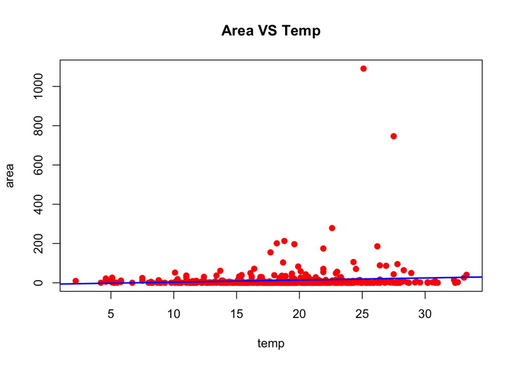

```r
plot(area ~ temp, data=forest.fires, col="red", pch=19, cex=1, main="Area VS Temp")
abline(reg1, col="blue", lwd=2)
```

# Focus on the left tail

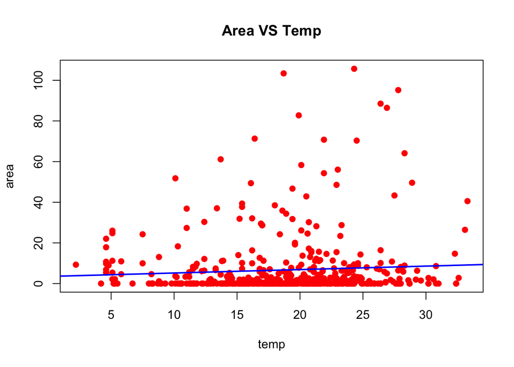

```r
plot(area ~ temp, data=forest.fires[y < 150,], col="red", pch=19, cex=1, main="Area VS Temp")
abline(lm(area ~ temp, data=forest.fires[forest.fires$area < 150,]), col="blue", lwd=2)
```

# Omitted variable bias?

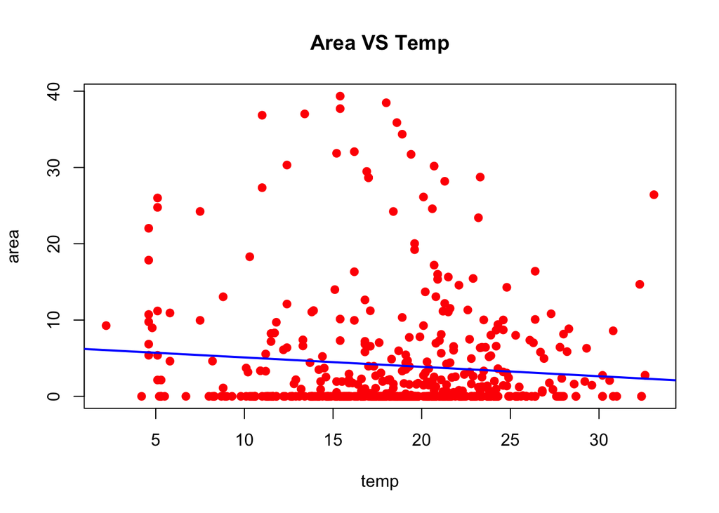

```r
plot(area ~ temp, data=forest.fires[y < 40,], col="red", pch=19, cex=1, main="Area VS Temp")
abline(lm(area ~ temp, data=forest.fires[forest.fires$area < 40,]), col="blue", lwd=2)
```

# Include more variables

```r
reg2 <- lm(area ~ temp + wind + rain + day + month, data=forest.fires)
summary(reg2)
```

```
##
## Call:
## lm(formula = area ~ temp + wind + rain + day + month, data = forest.fires)
##
## Residuals:
##     Min      1Q  Median      3Q     Max
##  -45.50  -15.46   -8.01    0.64 1050.40
##
## Coefficients:
##             Estimate Std. Error t value Pr(>|t|)
## (Intercept) -26.7401    25.8420  -1.035   0.3013
## temp          1.4998     0.6782   2.212   0.0275 *
## wind          1.9887     1.7434   1.141   0.2546
## rain         -2.7063     9.6926  -0.279   0.7802
## daymon        7.2646    10.4183   0.697   0.4859
## daysat       21.3027    10.0357   2.123   0.0343 *
## daysun        5.8056     9.7215   0.597   0.5507
## daythu       11.5690    10.9515   1.056   0.2913
## daytue        7.9059    10.8488   0.729   0.4665
## daywed        5.4513    11.3772   0.479   0.6320
## monthaug     -9.9727    22.8453  -0.437   0.6626
## monthdec     11.4417    31.1093   0.368   0.7132
## monthfeb      2.9437    25.9268   0.114   0.9097
## monthjan      1.3344    50.7041   0.026   0.9790
## monthjul     -9.6792    25.2222  -0.384   0.7013
## monthjun    -13.8577    27.0486  -0.512   0.6087
## monthmar     -6.9159    23.1904  -0.298   0.7657
## monthmay      4.5064    50.3496   0.090   0.9287
## monthnov     -7.8131    68.0906  -0.115   0.9087
## monthoct     -8.2799    27.4045  -0.302   0.7627
## monthsep      0.2729    22.6294   0.012   0.9904
## ---
## Signif. codes:  0 '***' 0.001 '**' 0.01 '*' 0.05 '.' 0.1 ' ' 1
##
## Residual standard error: 64.04 on 496 degrees of freedom
## Multiple R-squared:  0.02706,    Adjusted R-squared:  -0.01218
## F-statistic: 0.6897 on 20 and 496 DF,  p-value: 0.838
```

# Goodness of fit

$$\begin{equation}
\nonumber
MSE = \frac{1}{N} \sum_{i=1}^n (y_i - \hat{y}_i)^2
\end{equation}$$

$$\begin{equation}
\nonumber
R^2= 1- \frac{\sum_{i=1}^n (y_i - \hat{y}_i)^2}{\sum_{i=1}^n (y_i - \bar{y})^2}
\end{equation}$$

The $R^2$ reports the in-sample variance explained by the model. The higher the value the more the in-sample fit. Note that the $R^2$ is NOT a measure of the predictive power of the model.

# Make predictions

```r
y_hat <- predict(reg2, newdata=forest.fires)
print(mean((y-y_hat)^2))
```

```
## [1] 3934.804
```

```r
full <- lm(area ~., data=forest.fires)
y_hat <- predict(full, newdata=forest.fires)
print(mean((y-y_hat)^2))
```

```
## [1] 3859.072
```

*What happen to the R squared with more variables?*

- Remains the same
- Increses
- Decreases
- It depends on the variables
- We do not care

# R squared and Adjusted R Squared

For any variable introduced the $R^2$ increases , no matter the variable is meaningful or not.

$$\begin{equation}
\nonumber
Adj. R^2= 1- \frac{n-1}{n-k-1}\frac{\sum_{i=1}^n (y_i - \hat{y}_i)^2}{\sum_{i=1}^n (y_i - \bar{y})^2}
\end{equation}$$

Where $n$ is the number of observations and $k$ is the number of variables. Remember it still does not tell anything about the predictive power on new observations!

```r
summary(reg2)$r.squared
```

```
## [1] 0.02705633
```

```r
summary(full)$r.squared
```

```
## [1] 0.0457821
```

# Model Diagnosis

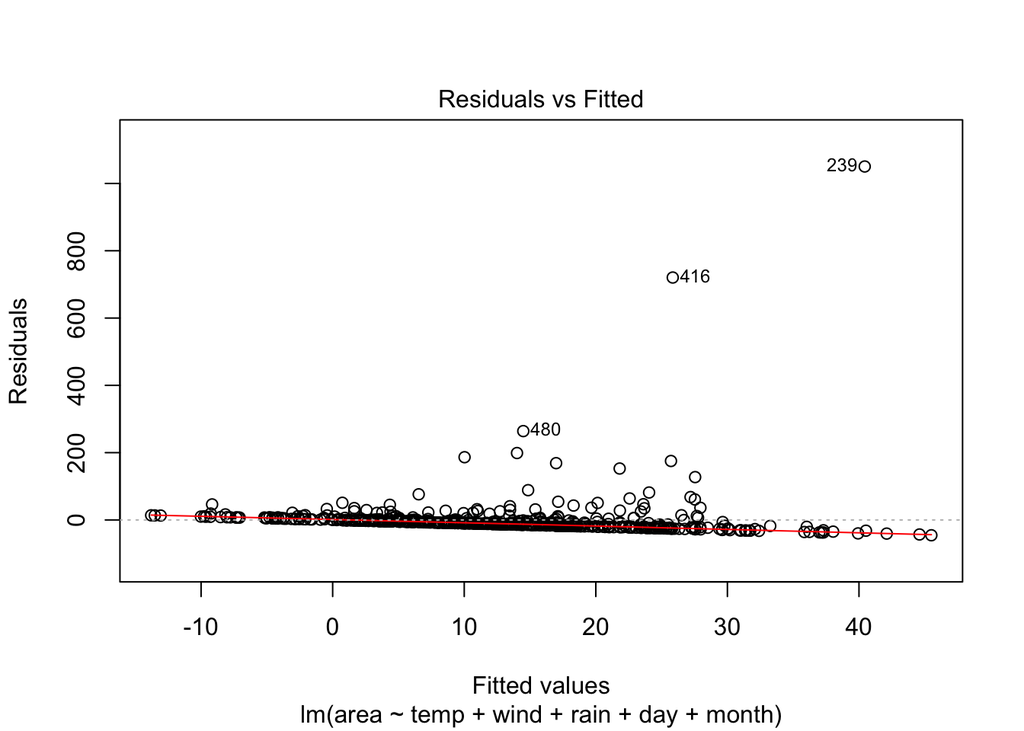

```r
plot(reg2, which=1)
```

```
## Warning: not plotting observations with leverage one:
##   517
```

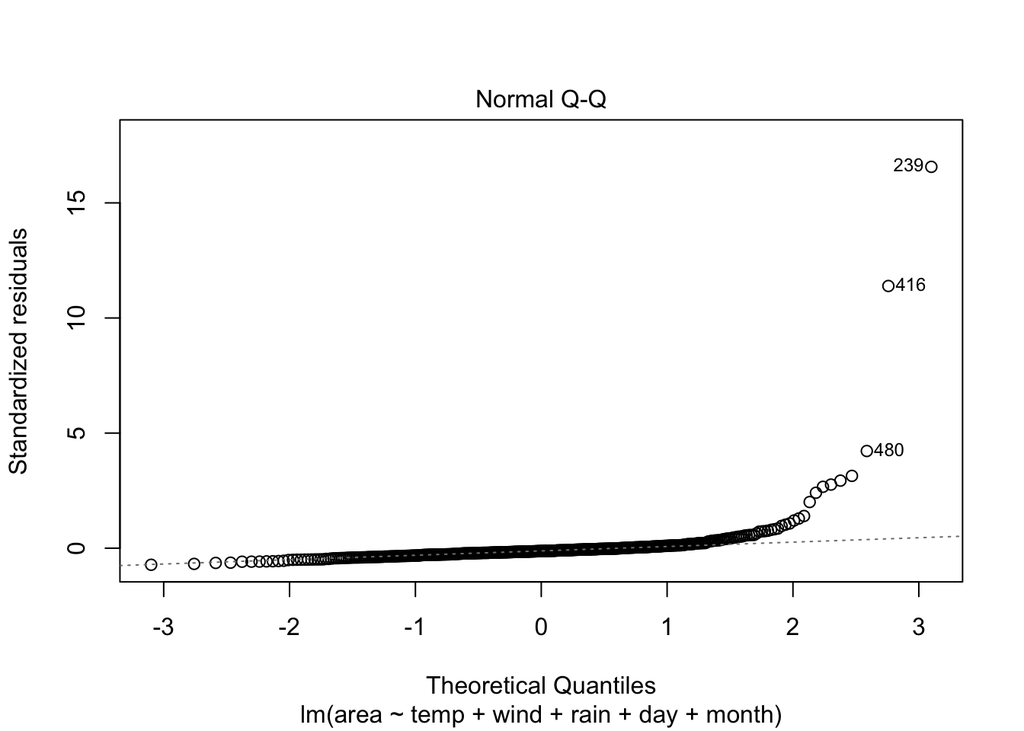

```r
plot(reg2, which=2)
```

Always look at the warning messages!

Cross Validated, R-Bloggers or Stack Overflow will be your best friends!

## Class Exercise

We want to predict which variable are the most correlated with the balance in a bank account.

To do so we use the credit data set , available in the package MABDA.

- Open the dataset
- Investigate the dimension fo the dataset and the variables at disposal
- Construct a univariate regression with Balance as a function of Income
- Plot a scatter plot of the regression (Hint: use abline() to draw the regression line)
- Look at the significance of the coefficients
- Write down their interpretation
- Construct a new model including a variable you might think it is important
- Predict the Balance account with the model and compute the in-sample mean squared error
- Repeat the process including 3, 4, 5, 8, 10 variables and draw the MSE as a function of the number of variables. Make the same plot for the R squared of each regression. What do you notice in both cases?

# Optional Challenge

- Pick randomly 4/5th observations from your dataset
- Construct the two following models:
- lm(Balance $\sim$ Income + Limit + Married, data = data.tr)
- lm(Balance $\sim$ Income + Limit + Married + Gender + Ethnicity + Age + Student , data= data.tr)
- Find the MSE on the remaining 1/5th of observations

What do you notice now?

Hint: You may want to have a look to the r script - lecture 1 on the web page before starting.

# Excercise in class: solutions

```r
Credit <- read.csv("./data/Credit.csv")
dim(Credit)
```

```
## [1] 400  12
```

```r
names(Credit)
```

```
##  [1] "X"         "Income"    "Limit"     "Rating"    "Cards"
##  [6] "Age"       "Education" "Gender"    "Student"   "Married"
## [11] "Ethnicity" "Balance"
```

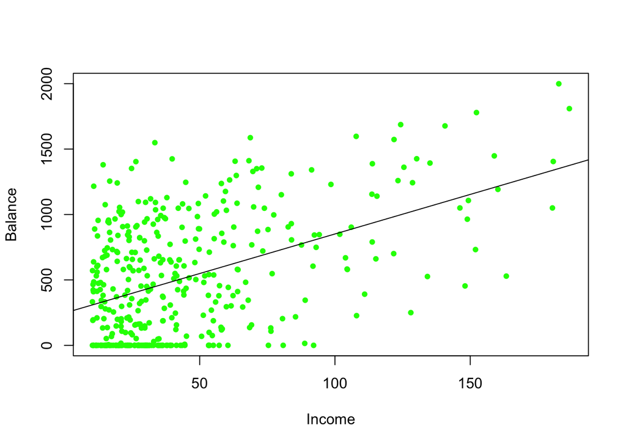

```r
reg1 <- lm(Balance ~ Income, data=Credit)
plot(Balance ~ Income, data=Credit, col="green", cex=0.7, pch=19)
abline(reg1)
```

```r
summary(reg1)
```

```
##
## Call:
## lm(formula = Balance ~ Income, data = Credit)
##
## Residuals:
##     Min      1Q  Median      3Q     Max
## -803.64 -348.99  -54.42  331.75 1100.25
##
## Coefficients:
##             Estimate Std. Error t value Pr(>|t|)
## (Intercept) 246.5148    33.1993   7.425  6.9e-13 ***
## Income        6.0484     0.5794  10.440  < 2e-16 ***
## ---
## Signif. codes:  0 '***' 0.001 '**' 0.01 '*' 0.05 '.' 0.1 ' ' 1
##
## Residual standard error: 407.9 on 398 degrees of freedom
## Multiple R-squared:  0.215,  Adjusted R-squared:  0.213
## F-statistic:   109 on 1 and 398 DF,  p-value: < 2.2e-16
```

```r
reg2 <- lm(Balance ~ Income + Age, data=Credit)
y_hat <- predict(reg2, newdata= Credit)
print(mean(Credit$Balance - y_hat)^2)
```

```
## [1] 1.844398e-25
```

```r
summary(reg2)
```

```
##
## Call:
## lm(formula = Balance ~ Income + Age, data = Credit)
##
## Residuals:
##     Min      1Q  Median      3Q     Max
## -864.15 -343.51  -51.42  317.95 1076.96
##
## Coefficients:
##             Estimate Std. Error t value Pr(>|t|)
## (Intercept) 359.6727    70.3583   5.112 4.97e-07 ***
## Income        6.2359     0.5868  10.628  < 2e-16 ***
## Age          -2.1851     1.1988  -1.823   0.0691 .
## ---
## Signif. codes:  0 '***' 0.001 '**' 0.01 '*' 0.05 '.' 0.1 ' ' 1
##
## Residual standard error: 406.7 on 397 degrees of freedom
## Multiple R-squared:  0.2215, Adjusted R-squared:  0.2176
## F-statistic: 56.47 on 2 and 397 DF,  p-value: < 2.2e-16
```

# Peak variables and compute MSE

```r
variables <- c(1,5,6,7,8,10,9,2,3,4)
mse <- rep(NA, length= 8)
r_squared <- rep(NA, length= 8)
```

# From 3 to 10 variables in the model

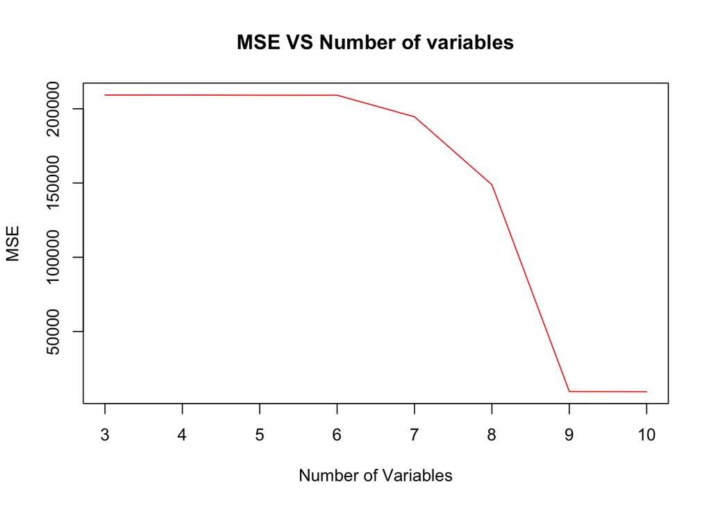

```r
for (i in 3:10){
  pick <- variables[c(1:i)]
  data <- Credit[,c(pick)]
  reg <- lm(Credit$Balance ~. , data= data)
  r_squared[i-2] <- summary(reg)$r.squared
  y_hat <- predict(reg) ## By default use data
  mse[i-2] <-  mean((Credit$Balance - y_hat)^2)
}

## Define type"n" to be able then to draw a line

plot(cbind(c(3:10), mse), xlab="Number of Variables", ylab="MSE", main="MSE VS Number of variables", type="n")
lines(cbind(c(3:10), mse), col="red", cex=1.2)
```

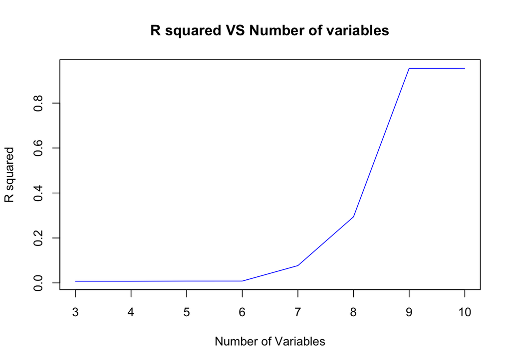

```r
plot(cbind(c(3:10), r_squared), xlab="Number of Variables", ylab="R squared", main="R squared VS Number of variables", type="n")
lines(cbind(c(3:10), r_squared), col="blue", cex=1.2)
```

# Challenging Exercise

```r
## Set seeds to replicate the result

set.seed(123)

## Pick randomly 1/5th of observastions
ii <- sample(nrow(Credit), floor(nrow(Credit)/5))

## Built a test and training set

data.te <- Credit[ii, ]
data.tr <- Credit[-ii,]

## Do your regressions on the training set
reg1 <- lm(Balance ~ Income + Limit + Married, data= data.tr)
reg2 <- lm(Balance ~ Income + Limit + Married + Gender + Ethnicity + Age + Student, data= data.tr )

## Make your predictions on the test set

y <- data.te$Balance


mse1 <- mean((y - predict(reg1, data=data.te))^2)
mse2 <- mean((y - predict(reg2, data=data.te))^2)
print(mse1)
```

```
## [1] 353538.7
```

```r
print(mse2)
```

```
## [1] 376461.7
```